# Introduction to Kormaps package

Keon-Woong Moon

2016-03-07

Kormaps 패키지는 한국지도를 이용하여 각종 통계자료와 행정구역을 연계하여 단계구분도(Choropleth map)을 쉽게 만들 수 있게 하기 위하여 패키지를 제작하였습니다. 한국행정지도 Shape파일은 통계지리정보서비스(sgis.go.kr)에서 제공하는 2010년 행정경계구역지도 Shape 파일을 국제규격에 맞게 형식을 변형한 후 빠른 속도로 단계구분도를 그릴 수 있도록 파일을 단순화하여 만들었습니다. Shape파일 단순화에 대한 자세한 내용은 패키지 제작자가 쓴 [“웹에서 클릭만으로 하는 R 통계분석(한나래,2015)”](http://www.aladin.co.kr/shop/wproduct.aspx?ItemId=66714863) 책을 참조하십시요. static image를 만들고자 할 때는 tmap패키지를 이용하면 쉽게 단계구분도를 그릴 수 있으며 웹상에서 축소/확대가 가능한 단계구분도를 그리고 싶을 때는 leaflet 패키지를 이용하면 좋습니다. 또한 국가통계포털(kosis.kr)에서 제공하는 2010년 인구총조사 데이타와 지도 데이타를 합친 데이터를 제공하므로 단계구분도를 연습해보는데 도움이 될 것입니다. 패키지에서 제공하는 행정구역지도 데이터는 다음과 같습니다.

- kormap1: 2010년 행정구역지도 level1(시/도별)
- kormap2: 2010년 행정구역지도 level2(시/군/구)
- kormap3: 2010년 행정구역지도 level3(읍/면/동)

2010년 인구통계와 병합된 지도데이타도 제공됩니다.

- korpopmap1: 2010년 행정구역지도 level1(시/도별) + 인구총조사(2010)
- korpopmap2: 2010년 행정구역지도 level2(시/군/구) + 인구총조사(2010)
- korpopmap3: 2010년 행정구역지도 level3(읍/면/동) + 인구총조사(2010)

## 패키지 설치하기

Kormaps 패키지는 CRAN에 등록되어 있지 않습니다. 한국행정구역 지도이기 때문에 함수에 한글이 포함되어 있어 CRAN에 등록하기 어렵습니다. 현재는 Github 에 저장되어 있으며 github에 있는 패키지를 설치하려면 먼저 devtools 패키지를 설치하여야 합니다. 이후 devtools 패키지의 install_github()함수를 이용하여 패키지를 설치합니다.

```r
install.packages("devtools")  # 한번 설치한 경우에는 다시 설치할 필요 없습니다.
devtools::install_github("cardiomoon/Kormaps")
```

## 행정구역 지도 그리기

Kormaps 패키지와 tmap 패키지를 이용하면 단계구분도를 쉽게 그릴 수 있습니다. 먼저 시도경계지도는 다음과 같이 그립니다.

```r
require(Kormaps)
require(Kormapsdata)
require(tmap)

qtm(kormap1)
```

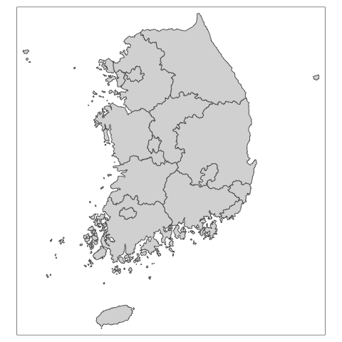

2010년 인구통계자료와 통합된 지도는 korpopmap1입니다. 다음은 총인구_명으로 구분된 단계구분도입니다.

```r
qtm(korpopmap1,"총인구_명",text="name")
```

[figure not shown]

인구통계자료에 포함된 항목은 다음과 같습니다.

```r
colnames(korpopmap1@data)
```

```
##  [1] "SP_ID"                   "FID"
##  [3] "code"                    "code1"
##  [5] "long"                    "lat"
##  [7] "order"                   "hole"
##  [9] "piece"                   "group"
## [11] "id"                      "FID.data"
## [13] "code.data"               "code.1"
## [15] "name"                    "name_eng"
## [17] "base_year"               "C행정구역별_읍면동"
## [19] "행정구역별_읍면동"       "시점"
## [21] "총인구_명"               "남자_명"
## [23] "여자_명"                 "내국인_계_명"
## [25] "내국인_남자_명"          "내국인_여자_명"
## [27] "외국인_계_명"            "외국인_남자_명"
## [29] "외국인_여자_명"          "가구_계_가구"
## [31] "일반가구_가구"           "집단가구_가구"
## [33] "외국인가구_가구"         "주택_계_호"
## [35] "단독주택_호"             "아파트_호"
## [37] "연립주택_호"             "다세대주택_호"
## [39] "비거주용_건물내_주택_호" "주택이외의_거처_호"
## [41] "region"                  "code1.data"
```

시/군/구 지도는 korpopmap2입니다.

```r
qtm(korpopmap2,"총인구_명")
```

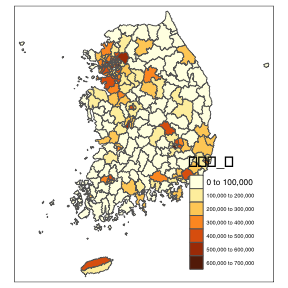

submap() 함수는 지도 중에서 원하는 지역만 골라서 지도를 그릴 수 있도록 해줍니다.

```r
Seoul2=submap(korpopmap2,"서울")
qtm(Seoul2,"외국인_계_명")
```

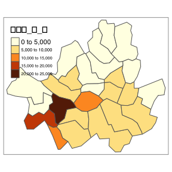

읍/면/동 지도는 korpopmap3입니다. 대구시의 읍/면/동 단계구분도를 보려면 다음과 같이 합니다.

```r
qtm(submap(korpopmap3,"대구"),"아파트_호")
```

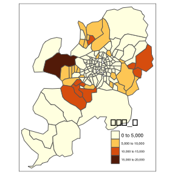

## leaflet을 이용한 동적인 지도

leaflet패키지는 자바를 이용하여 동적인 지도를 그려줍니다. Kormaps패키지에 포함되어 있는 myleaflet()함수는 여러 layer를 가지는 동적인 지도를 쉽게 구현해줍니다. 이 단계구분도는 축소/확대가 가능하고 클릭시 행정구역과 인구통계정보를 보여줍니다.

```r
require(leaflet)
myleaflet(korpopmap1,"총인구_명")
```

[interactive chart not shown]

또한 하나의 지도에 여러개의 layer를 넣는 것도 가능합니다.

```r
require(leaflet)
myleaflet(submap(korpopmap3,"광주"),choices=c("남자_명","여자_명","주택_계_호"))
```

[interactive chart not shown]

또한 이를 이용하여 웹 어플리케이션을 제작하는 것도 가능합니다. 다음 주소를 가보시면 이를 이용해 구현한 웹앱을 보실수 있습니다.

http://r-meta.com:3838/tmap2